# DEM 7223 - Event History Analysis - Parametric Hazard Models

## Using Longitudinal Data

As in the other examples, I illustrate fitting these models to data that are longitudinal, instead of person-duration.

In this example, we will examine how to fit the parametric model to a longitudinally collected data set. Here I use data from the [ECLS-K](http://nces.ed.gov/ecls/kinderdatainformation.asp). Specifically, we will examine the transition into poverty between kindergarten and third grade.

First we load our data First we load our data

```r
eclskk5<-readRDS("C:/Users/ozd504/OneDrive - University of Texas at San Antonio/classes/dem7223/dem7223_22//data/eclskk5.rds")
names(eclskk5)<-tolower(names(eclskk5))
```

```r
#get out only the variables I'm going to use for this example
myvars<-c( "childid","x_chsex_r", "x_raceth_r", "x1kage_r","x4age",
           "x5age", "x6age", "x7age", "x2povty","x4povty_i", "x6povty_i",
           "x8povty_i","x12par1ed_i", "s2_id")
eclskk5<-eclskk5[,myvars]
```

Recode variables:

```r
# time varying variables
eclskk5$age_1<-ifelse(eclskk5$x1kage_r==-9, NA, eclskk5$x1kage_r/12)
eclskk5$age_2<-ifelse(eclskk5$x4age==-9, NA, eclskk5$x4age/12)
#for the later waves, the NCES group the ages into ranges of months,
#so 1= <105 months, 2=105 to 108 months.
#So, I fix the age at the midpoint of the interval they give,
#and make it into years by dividing by 12

eclskk5$age_3<-ifelse(eclskk5$x5age==-9, NA, eclskk5$x5age/12)

eclskk5$pov_1<-ifelse(eclskk5$x2povty==1,1,0)
eclskk5$pov_2<-ifelse(eclskk5$x4povty_i==1,1,0)
eclskk5$pov_3<-ifelse(eclskk5$x6povty_i==1,1,0)


#Time constant variables
#Recode race with white, non Hispanic as reference using dummy vars
eclskk5$race_rec<-Recode (eclskk5$x_raceth_r, recodes="1 = 'nhwhite';2='nhblack';3:4='hispanic';5='nhasian'; 6:8='other';-9=NA", as.factor = T)
eclskk5$male<-Recode(eclskk5$x_chsex_r, recodes="1=1; 2=0; -9=NA")
eclskk5$mlths<-Recode(eclskk5$x12par1ed_i, recodes = "1:2=1; 3:9=0; else = NA")
eclskk5$mgths<-Recode(eclskk5$x12par1ed_i, recodes = "1:3=0; 4:9=1; else =NA")
```

**NOTE** I need to remove any children who are missing any of the necessary variables, and who are already in poverty in wave 1, because they are not at risk of experiencing **this particular** transition.

Again, this is called forming the *risk set*

```r
eclskk5<-eclskk5 %>% filter(is.na(pov_1)==F &
                  is.na(pov_2)==F &
                  is.na(pov_3)==F &
                  is.na(age_1)==F &
                  is.na(age_2)==F &
                  is.na(age_3)==F &
                    pov_1!=1)%>%
  mutate(povtran_1 =ifelse(pov_1==0 & pov_2==0, 0,1),
         povtran_2 = ifelse(povtran_1==1, NA,
                         ifelse(pov_2==0 & pov_3==0,0,1)))
```

Now we do the entire data set. To analyze data longitudinally, we need to reshape the data from the current “wide” format (repeated measures in columns) to a “long” format (repeated observations in rows).

The `pivot_long()` function allows us to do this easily. It allows us to specify our repeated measures, time varying covariates as well as time-constant covariates.

```r
e.long1 <- eclskk5 %>%
  #rename(wt = w4c4p_40,strata= w4c4p_4str, psu = w4c4p_4psu)%>%
  select(childid,male, race_rec, mlths, mgths,   #time constant
        age_1, age_2, age_3, #t-varying variables
         pov_1, pov_2, pov_3)%>%
   pivot_longer(cols = c(-childid, -male, -race_rec, -mlths, -mgths), #time constant variables go here
               names_to  = c(".value", "wave"), #make wave variable and put t-v vars into columns
               names_sep = "_") #all t-v variables have _ between name and time, like age_1, age_2
```

Now, I need to form the transition variable, this is my event variable, and in this case it will be 1 if a child enters poverty between the first wave of the data and the third grade wave, and 0 otherwise.

```r
e.long1 <- e.long1%>%
  group_by(childid)%>%
  mutate(nexpov = dplyr::lead(pov,n=1, order_by = childid))%>%
  mutate(povtran = ifelse(nexpov == 1 & pov == 0, 1, 0))




#find which kids failed in the first time period and remove them from the second risk period risk set
failed1<-which(is.na(e.long1$povtran)==T)
e.long1<-e.long1[-failed1,]

print(e.long1, n = 27)
```

```
# A tibble: 4,316 × 10
# Groups:   childid [2,072]
   childid   male race_rec mlths mgths wave    age   pov nexpov povtran
   <chr>    <dbl> <fct>    <dbl> <dbl> <chr> <dbl> <dbl>  <dbl>   <dbl>
 1 10000014     1 nhwhite      0     0 1      5.65     0      0       0
 2 10000014     1 nhwhite      0     0 2      7.16     0      0       0
 3 10000020     0 nhasian      0     0 1      5.70     0      0       0
 4 10000020     0 nhasian      0     0 2      7.38     0      0       0
 5 10000022     0 other        0     1 1      5.72     0      0       0
 6 10000022     0 other        0     1 2      7.31     0      0       0
 7 10000029     0 nhwhite      1     0 1      5.78     0      0       0
 8 10000029     0 nhwhite      1     0 2      7.24     0      0       0
 9 10000034     1 nhblack      0     0 1      6.35     0      0       0
10 10000034     1 nhblack      0     0 2      7.78     0      1       1
11 10000034     1 nhblack      0     0 3      8.30     1     NA       0
```

[output cut: 17 more lines]

So, this shows us the repeated measures nature of the longitudinal data set.

```r
#poverty transition based on mother's education at time 1.
fit<-survfit(Surv(time = age, event = povtran)~mlths, e.long1)
summary(fit)
```

```
Call: survfit(formula = Surv(time = age, event = povtran) ~ mlths,
    data = e.long1)

12 observations deleted due to missingness
                mlths=0
 time n.risk n.event survival  std.err lower 95% CI upper 95% CI
 5.00   3969       1    1.000 0.000252        0.999        1.000
 5.04   3947       1    0.999 0.000357        0.999        1.000
 5.08   3915       1    0.999 0.000439        0.998        1.000
 5.10   3903       1    0.999 0.000508        0.998        1.000
 5.12   3882       1    0.999 0.000569        0.998        1.000
 5.19   3793       1    0.998 0.000627        0.997        1.000
 5.21   3765       2    0.998 0.000730        0.997        0.999
 5.23   3739       1    0.998 0.000777        0.996        0.999
 5.24   3731       1    0.997 0.000822        0.996        0.999
 5.24   3726       1    0.997 0.000864        0.995        0.999
 5.26   3685       1    0.997 0.000905        0.995        0.999
 5.26   3682       1    0.997 0.000945        0.995        0.998
 5.27   3678       1    0.996 0.000983        0.994        0.998
 5.28   3656       1    0.996 0.001019        0.994        0.998
 5.29   3642       2    0.995 0.001090        0.993        0.998
 5.31   3609       1    0.995 0.001124        0.993        0.997
 5.33   3567       2    0.995 0.001190        0.992        0.997
 5.33   3555       1    0.994 0.001223        0.992        0.997
 5.36   3522       2    0.994 0.001285        0.991        0.996
 5.36   3517       1    0.994 0.001316        0.991        0.996
 5.36   3507       1    0.993 0.001345        0.991        0.996
 5.36   3503       1    0.993 0.001375        0.990        0.996
 5.37   3497       1    0.993 0.001403        0.990        0.995
 5.37   3491       2    0.992 0.001459        0.989        0.995
 5.38   3482       1    0.992 0.001486        0.989        0.995
 5.40   3441       1    0.992 0.001513        0.989        0.995
 5.41   3423       1    0.991 0.001540        0.988        0.994
 5.41   3410       1    0.991 0.001567        0.988        0.994
 5.42   3408       1    0.991 0.001593        0.988        0.994
 5.42   3393       2    0.990 0.001645        0.987        0.993
 5.43   3377       2    0.990 0.001696        0.986        0.993
 5.45   3337       1    0.989 0.001721        0.986        0.993
 5.45   3334       1    0.989 0.001746        0.985        0.992
 5.46   3327       1    0.989 0.001770        0.985        0.992
```

[output cut: 161 more lines]

```
 6.67    148       1    0.828 0.02554        0.779        0.880
 6.75    137       1    0.822 0.02606        0.772        0.875
 6.80    129       1    0.816 0.02662        0.765        0.869
 6.81    126       1    0.809 0.02719        0.758        0.864
 6.83    125       1    0.803 0.02773        0.750        0.859
 6.98     98       1    0.794 0.02863        0.740        0.853
 7.13     81       1    0.785 0.02991        0.728        0.845
 7.13     79       1    0.775 0.03114        0.716        0.838
 7.14     78       1    0.765 0.03228        0.704        0.831
 7.19     73       1    0.754 0.03350        0.691        0.823
 7.25     60       1    0.742 0.03522        0.676        0.814
 7.30     53       1    0.728 0.03723        0.658        0.804
 7.53     29       1    0.703 0.04359        0.622        0.793
 7.55     26       1    0.676 0.04959        0.585        0.780
 7.61     21       1    0.643 0.05671        0.541        0.765
```

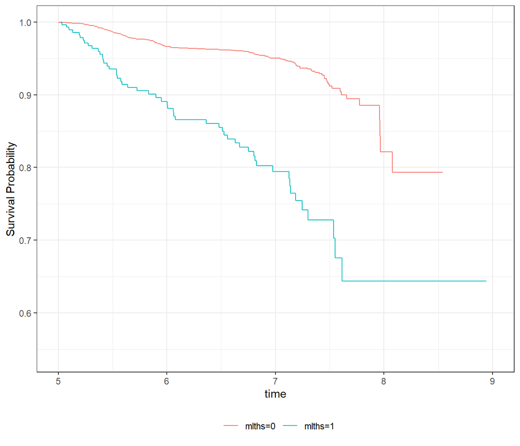

```r
fit%>%
ggsurvfit(conf.int = T,
           risk.table = F,
           title = "Survivorship Function for Poverty Transition",
           xlab = "Wave of survey")+
  xlim(5, 9)
```

```r
#Exponential
#interval censored
fitl1<-phreg(Surv(time = age, event = povtran)~mlths+mgths+race_rec, data=e.long1,
             dist = "weibull",
             shape=1)
summary(fitl1)
```

```
Covariate             Mean       Coef     Rel.Risk   S.E.    LR p
mlths                 0.067     0.370     1.448     0.186   0.0494
mgths                 0.764    -1.034     0.355     0.161   0.0000
race_rec                                                    0.0000
        hispanic      0.240     0         1 (reference)
         nhasian      0.082    -0.578     0.561     0.289
         nhblack      0.066     0.012     1.012     0.241
         nhwhite      0.541    -0.991     0.371     0.178
           other      0.070    -0.268     0.765     0.286

Events                    223
Total time at risk         27574
Max. log. likelihood      -1215.1
LR test statistic         164.31
Degrees of freedom        6
Overall p-value           0
```

```r
#Weibull
fitl2<-phreg(Surv(time = age, event = povtran)~mlths+mgths+race_rec, data=e.long1
             , dist = "weibull")
summary(fitl2)
```

```
Covariate             Mean       Coef     Rel.Risk   S.E.    LR p
mlths                 0.067     0.403     1.496     0.186   0.0321
mgths                 0.764    -0.934     0.393     0.161   0.0000
race_rec                                                    0.0000
        hispanic      0.240     0         1 (reference)
         nhasian      0.082    -0.508     0.602     0.289
         nhblack      0.066    -0.013     0.987     0.241
         nhwhite      0.541    -1.010     0.364     0.177
           other      0.070    -0.305     0.737     0.285

Events                    223
Total time at risk         27574
Max. log. likelihood      -933.15
LR test statistic         153.23
Degrees of freedom        6
Overall p-value           0
```

```r
#Piecewise constant
fitl3<-pchreg(Surv(time = age, event = povtran)~mlths+mgths+race_rec,data=e.long1, cuts = c(5,6, 7, 8))
#summary(fitl3)

#AIC for exponential
AIC(fitl1)
```

```
[1] 2444.279
```

```r
AIC(fitl2)
```

```
[1] 1882.293
```

```r
-2*fitl3$loglik[2]+length(coef(fitl3))
```

```
[1] 1721.913
```

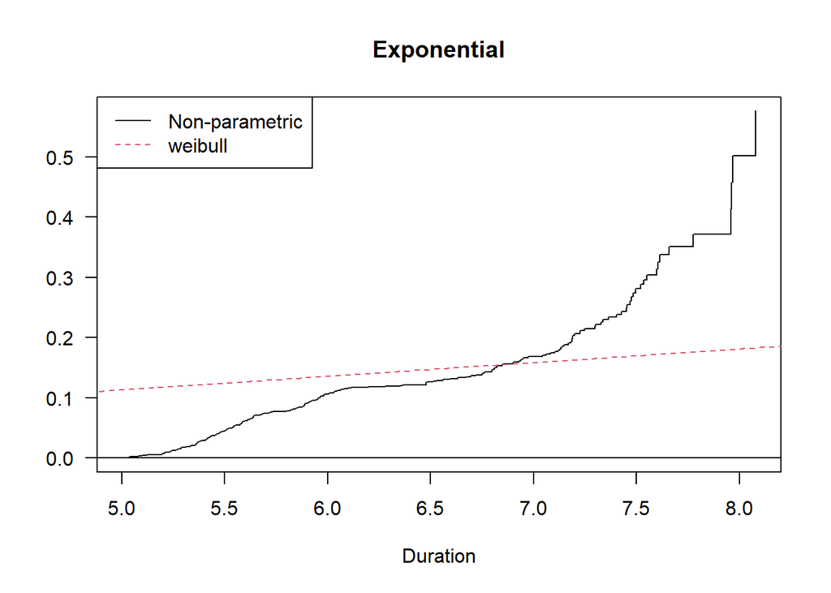

```r
#Empirical (Cox)
fitle<-coxreg(Surv(time = age, event = povtran)~mlths+mgths+race_rec, data=e.long1)

check.dist(fitle, fitl1, main = "Exponential")
```

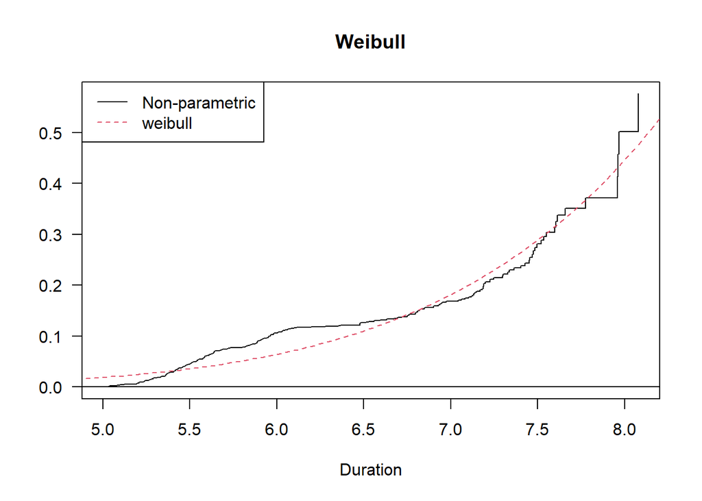

```r
check.dist(fitle, fitl2, main = "Weibull")
```

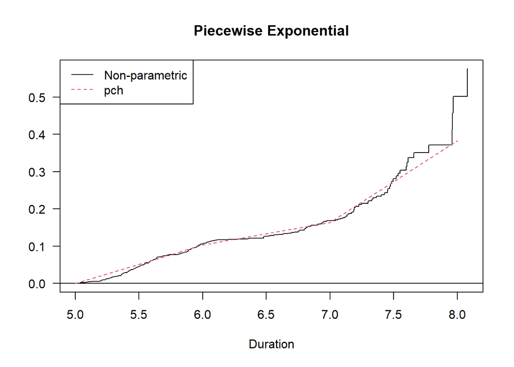

```r
check.dist(fitle, fitl3, main = "Piecewise Exponential")
```

According to the AIC and the fit plot, the piecewise model is fitting better here.